# Exploring the BRFSS data

## Setup

### Load packages

```r
library(ggplot2)
library(dplyr)
```

### Load data

```r
load("brfss2013.RData")
```

## Part 1: Data

The data was collected by a telephone survey. This could create bias depending on what time the surveyors called. If it was during working hours, it could create a bias towards people who are currently not working due to retirement or other factors.

There was no control group, but the participants in the survey were randomly selected. This means that we can make correlational statements and generalize to the entire population, but we cannot make causal statments.

## Part 2: Research questions

**Research quesion 1:** Of the people who never wear seatbelts, are they more or less likely to have a serious illness such as cancer?

**Research quesion 2:** Those who think of race the most, are they more or less likely to be in good health?

**Research quesion 3:** What income bracket do those who work the most hours fall into?

## Part 3: Exploratory data analysis

**Research quesion 1:** I chose this question because it makes sense to me that people who don’t wear a seatbelt might be less afraid of dying because they already have a serious illness. I created some bar graphs and looked at the numbers of people who never wear a seatbelt and have cancer, and then compared the percentages with the rest of the population.

We can see the breakdown of responses to the question: “Do you wear a seatbelt?”

```r
table(brfss2013$seatbelt)
```

```
##
##                       Always                Nearly always
##                       390327                        34494
##                    Sometimes                       Seldom
##                        13718                         5708
##                        Never Never drive or ride in a car
##                         7445                         1148
```

There is a small amount of people who never wear a seatbelt. I was very interested in them. I was curious if people who never wear a seatbelt may have a serious illness that might make them not care about car accidents.

```r
never_wear <- brfss2013 %>%
  filter(seatbelt == "Never")
```

This will create a new dataset composed of people who say they never wear a seatbelt

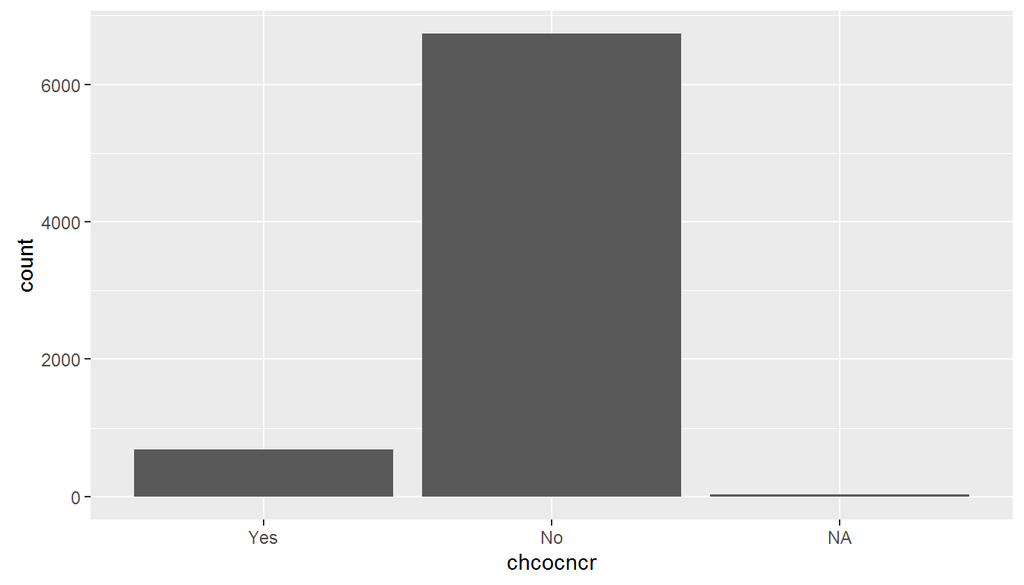

```r
ggplot(data = never_wear, aes(chcocncr)) + geom_bar()
```

This will make a bar chart that shows the breakdown of people who never wear a seatbelt who were told they have cancer Running the table function on this will help us get a percent.

```r
table(never_wear$chcocncr)
```

```
##
##  Yes   No
##  683 6733
```

```r
Yes <- 683
No <- 6733
Percent_Yes <- Yes / (Yes + No)
Percent_Yes
```

```
## [1] 0.09209817
```

We will now do the same thing with the entire dataset.

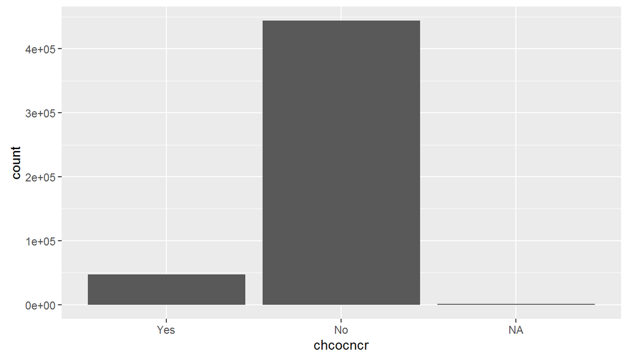

```r
ggplot(data = brfss2013, aes(chcocncr)) + geom_bar()
```

```r
table(brfss2013$chcocncr)
```

```
##
##    Yes     No
##  47074 443553
```

```r
Yes <- 47074
No <- 443553
Percent_Yes <- Yes / (Yes + No)
Percent_Yes
```

```
## [1] 0.09594662
```

This shows us that 9.5% have cancer in the entire sample So, almost the same as the people who never wear seatbelts.

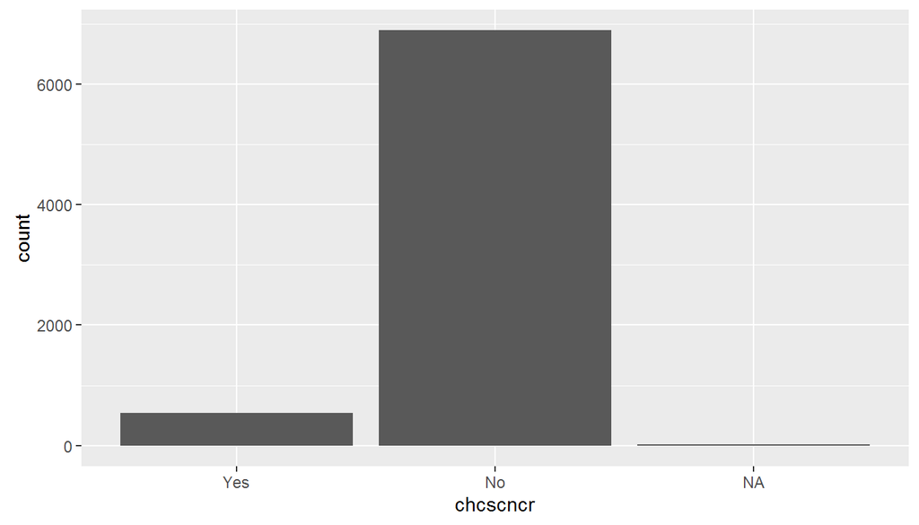

```r
ggplot(data = never_wear, aes(chcscncr)) + geom_bar()
```

This shows the people who never wear a seatbelt and have been told that they have skin cancer.

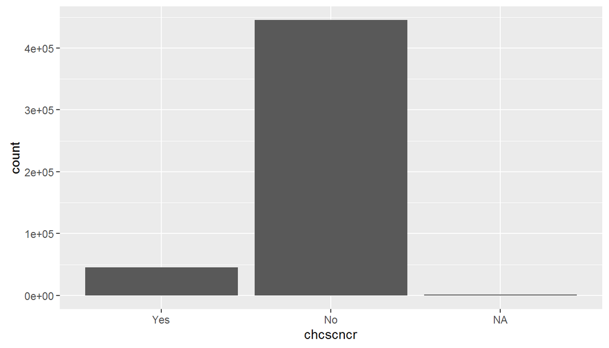

```r
ggplot(data = brfss2013, aes(chcscncr)) + geom_bar()
```

This is the entire sample for comparison.

I will run tables on both to get the numbers and percents.

```r
table(never_wear$chcscncr)
```

```
##
##  Yes   No
##  538 6887
```

```r
table(brfss2013$chcscncr)
```

```
##
##    Yes     No
##  45446 445020
```

```r
s_yes <- 538
s_no <- 6887
s_cancer <- s_yes / (s_yes + s_no)
s_cancer
```

```
## [1] 0.07245791
```

This prints out the percentage of people who never wear a seatbelt and have been told that they have skin cancer

```r
yes <- 45446
no <- 445020
cancer <- yes / (yes + no)
cancer
```

```
## [1] 0.09265882
```

This does the same for the entire sample.

7.2% of those who never wear seat belts have been told that they have skin cancer and 9.3% of the entire sample has been told that they have skin cancer. We cannot say there is any correlation between having cancer and wearing your seatbelt. **Research quesion 2:** I chose this research question because it made sense to me that people who constantly think of race must be in a negative state of mind. This may have an impact on their overall health compared to the total sample.

First, I filtered out people who constantly think of race into a new dataset.

```r
race_thoughts <- brfss2013 %>%
  filter(rrcognt2 == "Constantly")
```

I looked at their general health compared to the rest of the sample. The first chart shows the people who constantly think about race

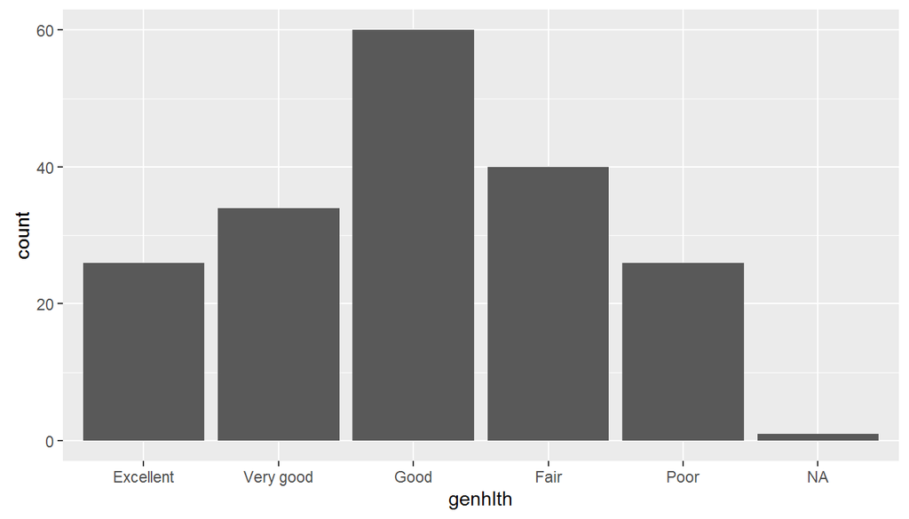

```r
ggplot(data = race_thoughts, aes(x = genhlth)) + geom_bar()
```

And this chart shows the same chart, but with the entire dataset

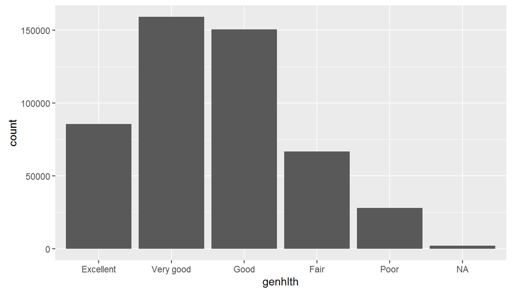

```r
ggplot(data = brfss2013, aes(x = genhlth)) + geom_bar()
```

Running a table on each I can get numbers and compare the percentages. First is the table for the entire population

```r
table(brfss2013$genhlth)
```

```
##
## Excellent Very good      Good      Fair      Poor
##     85482    159076    150555     66726     27951
```

Next is the table for the group that constantly thinks about race

```r
table(race_thoughts$genhlth)
```

```
##
## Excellent Very good      Good      Fair      Poor
##        26        34        60        40        26
```

I then made variables containing percentages for general health. The first two contain the percentage of people who consider themselves in fair health or poor health and constantly think about race

```r
r_fair <- 40 / 187
r_poor <- 26 / 187
```

The next two are the percentages of people who consider themselves in fair or poor health from the entire sample

```r
fair <- 66726 / 491775
poor <-  27951 / 491775
```

```r
r_fair
```

```
## [1] 0.2139037
```

```r
r_poor
```

```
## [1] 0.1390374
```

This shows us the percentages for people who constantly think about race.

```r
fair
```

```
## [1] 0.135684
```

```r
poor
```

```
## [1] 0.05683697
```

And these are the entire sample for comparison

Running the percentages on these I found that those that think about race constantly have a higher percentage of people in poor or fair health compared to the general population.

Think about race constantly:

```
Poor Health = 13.9%

Fair Health = 21.4%
```

Total sample:

```
Poor Health = 5.7%

Fair Health = 13.6%
```

This could be due to the very small sample of people who constantly think about race compared to the entire sample, which is quite large. But, based on the results, we can say there is correlation between thinking about race and general health.

**Research quesion 3:** In America, we believe that if you work harder you will be compensated for it. Whether this is always true or not is an entirely different story. I wanted to see if the people in our sample who work the most also get paid the most.

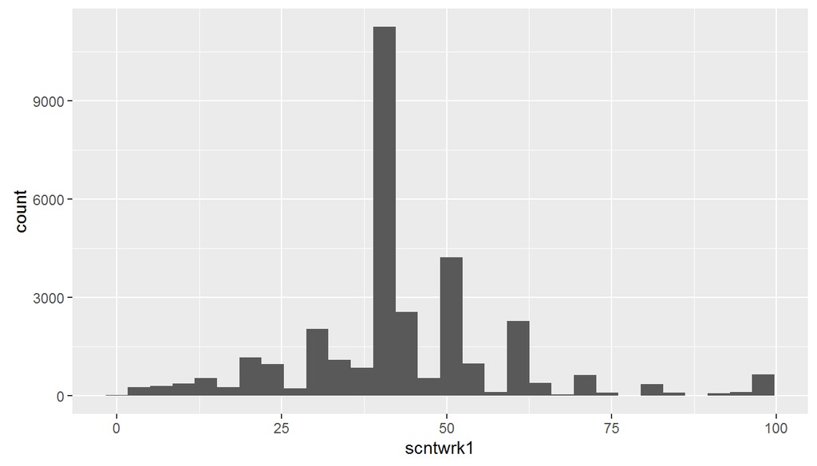

```r
ggplot(data = brfss2013, aes(x = scntwrk1)) + geom_histogram()
```

```r
brfss2013 %>%
  summarise(mean_hr = mean(scntwrk1, na.rm = TRUE), sd_hr = sd(scntwrk1, na.rm = TRUE))
```

```
##    mean_hr    sd_hr
## 1 43.03659 15.85198
```

We can see that the mean of the data is 43 hours a week with a standard deviation of 15.85 hours.

```r
brfss2013 <- brfss2013 %>%
  mutate(high_hours = ifelse(scntwrk1 >= 50, "high", "low"))
```

This will create a new column in the brfss2013 dataset based on hours worked. I assigned everyone who works more than 50 hours a week as ‘high’, and everyone else as ‘low’.

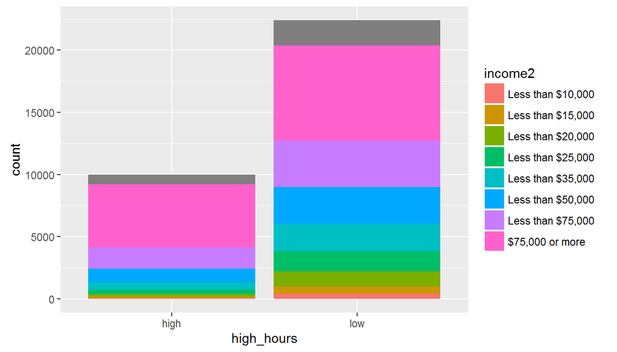

```r
ggplot(data = brfss2013, aes(x = high_hours, fill = income2)) + geom_bar()
```

```r
table(brfss2013$high_hours)
```

```
##
##  high   low
##  9970 22392
```

This table shows us how many are in the high category, and how many are in the low category.

```r
total <- 9970 + 22392
high <- 9970
low <- 22392
```

These variables will help us get the breakdown by percentage.

```r
high / total
```

```
## [1] 0.3080774
```

This is the percentage of people in the high category.

```r
low / total
```

```
## [1] 0.6919226
```

And this is the percentage of people in the low category.

We can see that out of the people who completed this question in the survey (32,362), 31% are in the high category and 69% are in the low category. Or in other words, 69% of the people surveyed work less than 50 hours a week.

Breaking this down by income we can see the following.

```r
high_hours <- brfss2013 %>%
  filter(high_hours == "high")
```

This creates a new dataset for people that we classified as being in the ‘high’ hours category.

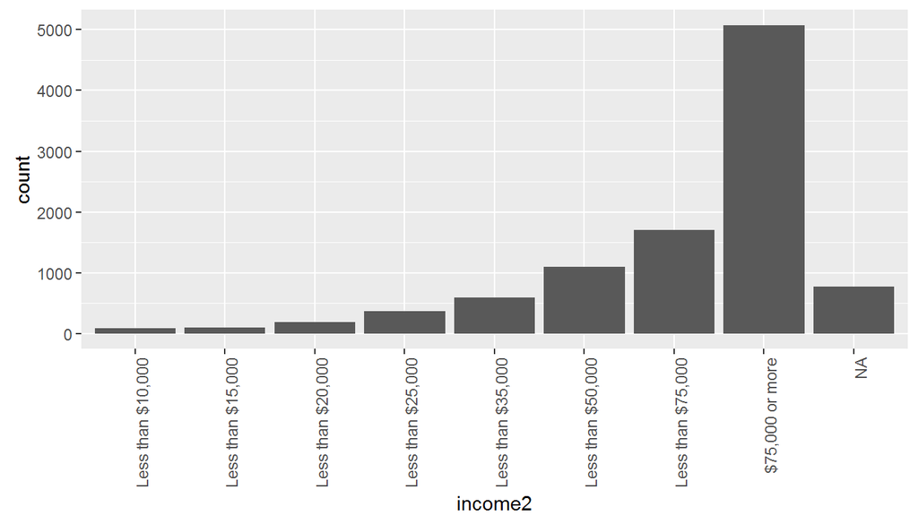

```r
ggplot(data = high_hours, aes(x = income2)) + theme(axis.text.x = element_text(angle = 90, hjust = 1)) + geom_bar()
```

```r
table(high_hours$income2)
```

```
##
## Less than $10,000 Less than $15,000 Less than $20,000 Less than $25,000
##                86                99               190               370
## Less than $35,000 Less than $50,000 Less than $75,000   $75,000 or more
##               587              1091              1703              5076
```

This graph and table shows us how they are broken down

```r
low_hours <- brfss2013 %>%
  filter(high_hours == "low")
```

This table and graph does the same thing, but now for the people who are in the ‘low’ category.

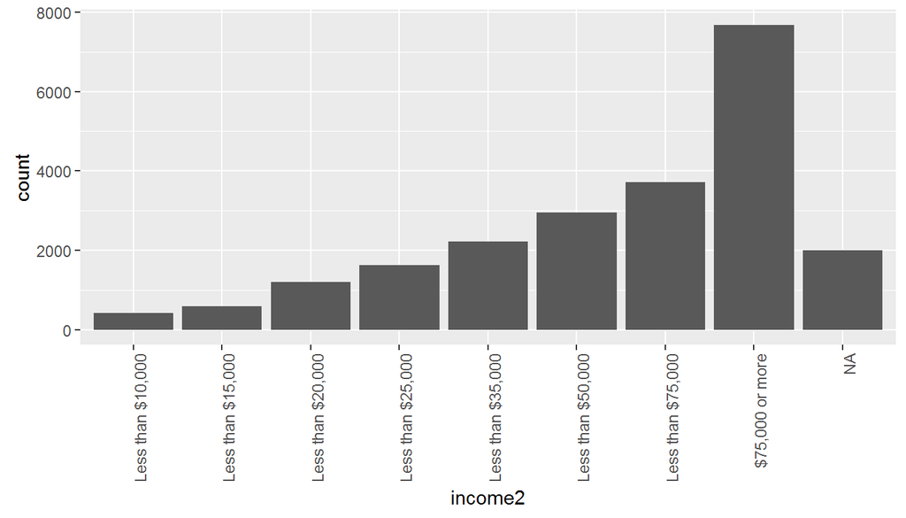

```r
ggplot(data = low_hours, aes(x = income2)) + theme(axis.text.x = element_text(angle = 90, hjust = 1)) + geom_bar()
```

```r
table(low_hours$income2)
```

```
##
## Less than $10,000 Less than $15,000 Less than $20,000 Less than $25,000
##               414               593              1206              1618
## Less than $35,000 Less than $50,000 Less than $75,000   $75,000 or more
##              2215              2949              3715              7681
```

We can see from the two charts that in both categories the income bracket $75,000 or more is the largest bar. This is not reflective of the entire US population and is probably due to the bias introduced by conducting a telephone interview.

If we do some analysis on the numbers given by the tables we can come up with the following:

```r
5076/high
```

```
## [1] 0.5091274
```

This gives us the percentage of people who work more than 50 hours a work and make $75,000 or more a year.

```r
7681/low
```

```
## [1] 0.3430243
```

This gives us the percentage of people who work less than 50 hours a week and make $75,000 or more a year. So, we can say that there is a correlation between working more hours and pay bracket.